# Homework_1

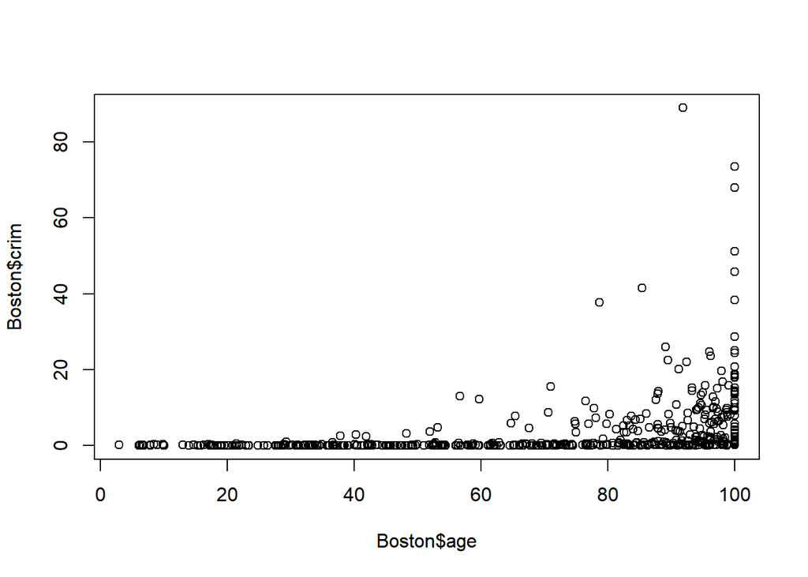

```r
plot(Boston$age, Boston$crim)
```

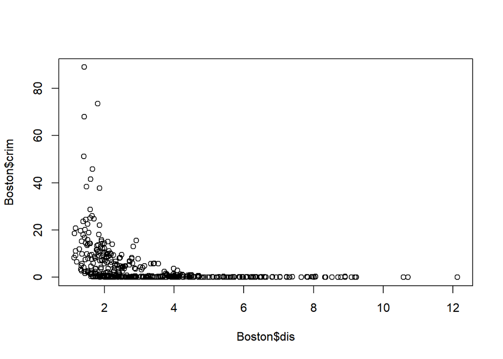

```r
plot(Boston$dis, Boston$crim)
```

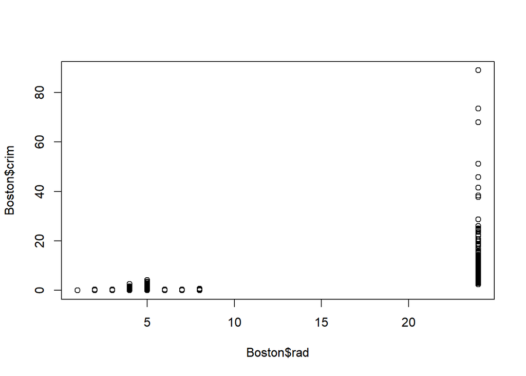

```r
plot(Boston$rad, Boston$crim)
```

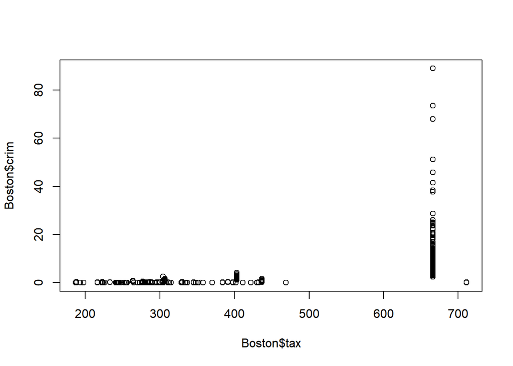

```r
plot(Boston$tax, Boston$crim)
```

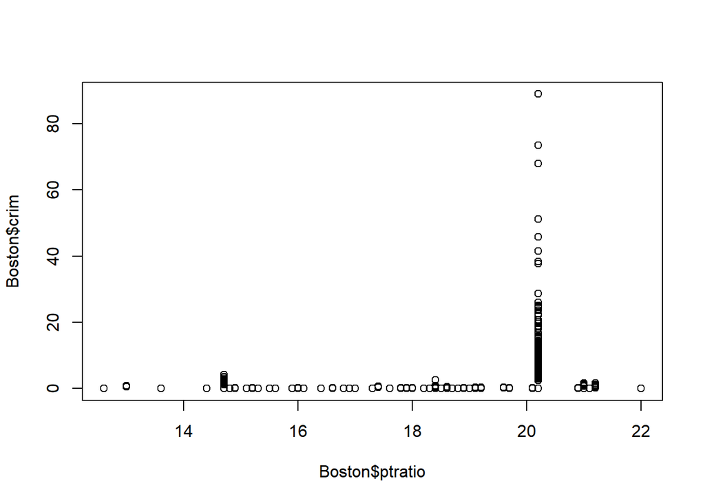

```r
plot(Boston$ptratio, Boston$crim)
```

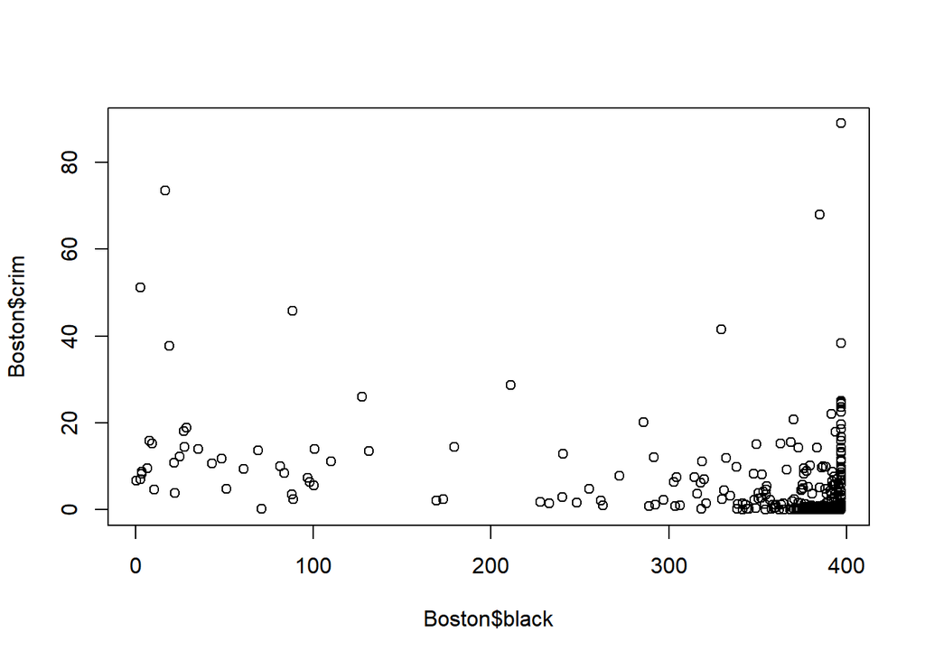

```r
plot(Boston$black, Boston$crim)
```

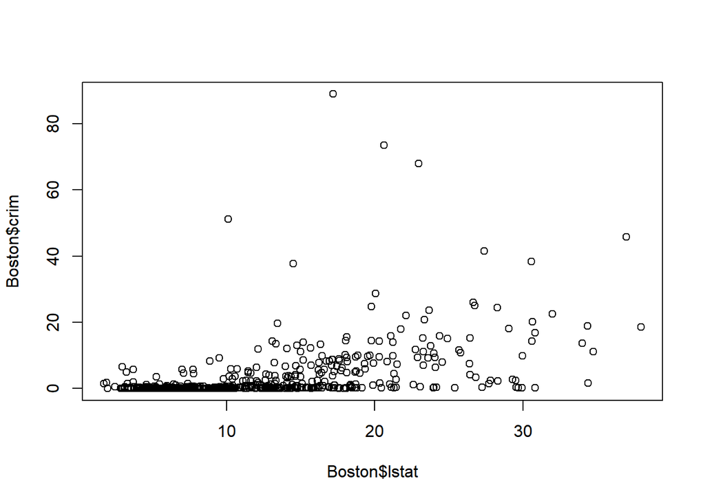

```r
plot(Boston$lstat, Boston$crim)
```

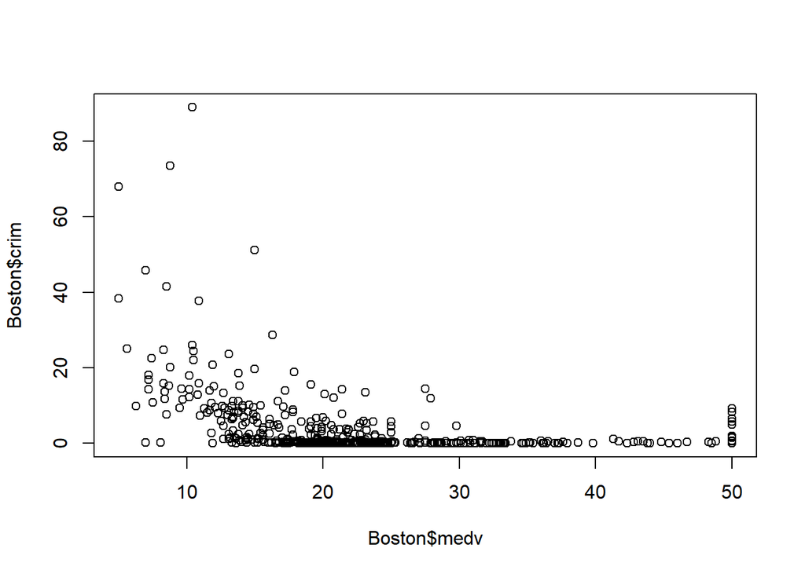

```r
plot(Boston$medv, Boston$crim)
```

According to the P values of all models, all variables are statistically significant predictors of crim, except for chas.

### b)

```r
model_b = lm(crim ~ zn + indus + chas + nox + rm + age + dis + rad + tax + ptratio + black + lstat + medv, Boston)
summary(model_b)
```

```
##
## Call:
## lm(formula = crim ~ zn + indus + chas + nox + rm + age + dis +
##     rad + tax + ptratio + black + lstat + medv, data = Boston)
##
## Residuals:
##    Min     1Q Median     3Q    Max
## -9.924 -2.120 -0.353  1.019 75.051
##
## Coefficients:
##               Estimate Std. Error t value Pr(>|t|)
## (Intercept)  17.033228   7.234903   2.354 0.018949 *
## zn            0.044855   0.018734   2.394 0.017025 *
## indus        -0.063855   0.083407  -0.766 0.444294
## chas         -0.749134   1.180147  -0.635 0.525867
## nox         -10.313535   5.275536  -1.955 0.051152 .
## rm            0.430131   0.612830   0.702 0.483089
## age           0.001452   0.017925   0.081 0.935488
## dis          -0.987176   0.281817  -3.503 0.000502 ***
## rad           0.588209   0.088049   6.680 6.46e-11 ***
## tax          -0.003780   0.005156  -0.733 0.463793
## ptratio      -0.271081   0.186450  -1.454 0.146611
## black        -0.007538   0.003673  -2.052 0.040702 *
## lstat         0.126211   0.075725   1.667 0.096208 .
## medv         -0.198887   0.060516  -3.287 0.001087 **
## ---
## Signif. codes:  0 '***' 0.001 '**' 0.01 '*' 0.05 '.' 0.1 ' ' 1
##
## Residual standard error: 6.439 on 492 degrees of freedom
## Multiple R-squared:  0.454,  Adjusted R-squared:  0.4396
## F-statistic: 31.47 on 13 and 492 DF,  p-value: < 2.2e-16
```

If the alpha level is 0.05, we can reject the null hypothesis for the predictors: zn,dis,rad,black and medv. The P-value of these predictors are lower than 0.05.

### c)

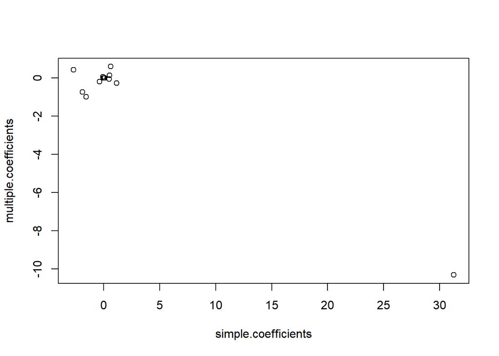

```r
simple.coefficients = c(coefficients(model.zn)[2], coefficients(model.indus)[2],
                        coefficients(model.chas)[2], coefficients(model.nox)[2],
                        coefficients(model.rm)[2], coefficients(model.age)[2],
                        coefficients(model.dis)[2], coefficients(model.rad)[2],
                        coefficients(model.tax)[2], coefficients(model.ptratio)[2],
                        coefficients(model.black)[2], coefficients(model.lstat)[2],
                        coefficients(model.medv)[2])
multiple.coefficients = coefficients(model_b)[2:14]
plot(simple.coefficients, multiple.coefficients)
```

All the variable are clustered in the top left corner, except one variable. Let’s find which variable is so special:

```r
simple.coefficients
```

```
##          zn       indus        chas         nox          rm         age
## -0.07393498  0.50977633 -1.89277655 31.24853120 -2.68405122  0.10778623
##         dis         rad         tax     ptratio       black       lstat
## -1.55090168  0.61791093  0.02974225  1.15198279 -0.03627964  0.54880478
##        medv
## -0.36315992
```

The variable in the bottom right corner is nox.

### d)

```r
model.zn.nonlinear = lm(crim ~ poly(zn, 3), Boston)
model.indus.nonlinear = lm(crim ~ poly(indus, 3), Boston)
model.chas.nonlinear = lm(crim ~ chas + I(chas^2) + I(chas^3), Boston)
model.nox.nonlinear = lm(crim ~ poly(nox, 3), Boston)
model.rm.nonlinear = lm(crim ~ poly(rm, 3), Boston)
model.age.nonlinear = lm(crim ~ poly(age, 3), Boston)
model.dis.nonlinear = lm(crim ~ poly(dis, 3), Boston)
model.rad.nonlinear = lm(crim ~ poly(rad, 3), Boston)
model.tax.nonlinear = lm(crim ~ poly(tax, 3), Boston)
model.ptratio.nonlinear = lm(crim ~ poly(ptratio, 3), Boston)
model.black.nonlinear = lm(crim ~ poly(black, 3), Boston)
model.lstat.nonlinear = lm(crim ~ poly(lstat, 3), Boston)
model.medv.nonlinear = lm(crim ~ poly(medv, 3), Boston)

anova(model.zn, model.zn.nonlinear)
```

```
## Analysis of Variance Table
##
## Model 1: crim ~ zn
## Model 2: crim ~ poly(zn, 3)
##   Res.Df   RSS Df Sum of Sq      F   Pr(>F)
## 1    504 35862
## 2    502 35187  2    674.56 4.8118 0.008512 **
## ---
## Signif. codes:  0 '***' 0.001 '**' 0.01 '*' 0.05 '.' 0.1 ' ' 1
```

```r
anova(model.indus, model.indus.nonlinear)
```

```
## Analysis of Variance Table
##
## Model 1: crim ~ indus
## Model 2: crim ~ poly(indus, 3)
##   Res.Df   RSS Df Sum of Sq      F    Pr(>F)
## 1    504 31187
## 2    502 27662  2    3525.1 31.987 8.409e-14 ***
## ---
## Signif. codes:  0 '***' 0.001 '**' 0.01 '*' 0.05 '.' 0.1 ' ' 1
```

```r
anova(model.chas, model.chas.nonlinear)
```

```
## Analysis of Variance Table
##
## Model 1: crim ~ chas
## Model 2: crim ~ chas + I(chas^2) + I(chas^3)
##   Res.Df   RSS Df Sum of Sq F Pr(>F)
## 1    504 37247
## 2    504 37247  0         0
```

```r
anova(model.nox, model.nox.nonlinear)
```

```
## Analysis of Variance Table
##
## Model 1: crim ~ nox
## Model 2: crim ~ poly(nox, 3)
##   Res.Df   RSS Df Sum of Sq      F    Pr(>F)
## 1    504 30742
## 2    502 26267  2    4474.6 42.758 < 2.2e-16 ***
## ---
## Signif. codes:  0 '***' 0.001 '**' 0.01 '*' 0.05 '.' 0.1 ' ' 1
```

```r
anova(model.rm, model.rm.nonlinear)
```

```
## Analysis of Variance Table
##
## Model 1: crim ~ rm
## Model 2: crim ~ poly(rm, 3)
##   Res.Df   RSS Df Sum of Sq      F   Pr(>F)
## 1    504 35567
## 2    502 34831  2    736.69 5.3088 0.005229 **
## ---
## Signif. codes:  0 '***' 0.001 '**' 0.01 '*' 0.05 '.' 0.1 ' ' 1
```

```r
anova(model.age, model.age.nonlinear)
```

```
## Analysis of Variance Table
##
## Model 1: crim ~ age
## Model 2: crim ~ poly(age, 3)
##   Res.Df   RSS Df Sum of Sq     F    Pr(>F)
## 1    504 32714
## 2    502 30853  2      1861 15.14 4.125e-07 ***
## ---
## Signif. codes:  0 '***' 0.001 '**' 0.01 '*' 0.05 '.' 0.1 ' ' 1
```

```r
anova(model.dis, model.dis.nonlinear)
```

```
## Analysis of Variance Table
##
## Model 1: crim ~ dis
## Model 2: crim ~ poly(dis, 3)
##   Res.Df   RSS Df Sum of Sq     F    Pr(>F)
## 1    504 31977
## 2    502 26983  2    4994.5 46.46 < 2.2e-16 ***
## ---
## Signif. codes:  0 '***' 0.001 '**' 0.01 '*' 0.05 '.' 0.1 ' ' 1
```

```r
anova(model.rad, model.rad.nonlinear)
```

```
## Analysis of Variance Table
##
## Model 1: crim ~ rad
## Model 2: crim ~ poly(rad, 3)
##   Res.Df   RSS Df Sum of Sq      F  Pr(>F)
## 1    504 22745
## 2    502 22417  2    328.06 3.6733 0.02608 *
## ---
## Signif. codes:  0 '***' 0.001 '**' 0.01 '*' 0.05 '.' 0.1 ' ' 1
```

```r
anova(model.tax, model.tax.nonlinear)
```

```
## Analysis of Variance Table
##
## Model 1: crim ~ tax
## Model 2: crim ~ poly(tax, 3)
##   Res.Df   RSS Df Sum of Sq     F    Pr(>F)
## 1    504 24674
## 2    502 23581  2    1093.5 11.64 1.144e-05 ***
## ---
## Signif. codes:  0 '***' 0.001 '**' 0.01 '*' 0.05 '.' 0.1 ' ' 1
```

```r
anova(model.ptratio, model.ptratio.nonlinear)
```

```
## Analysis of Variance Table
##
## Model 1: crim ~ ptratio
## Model 2: crim ~ poly(ptratio, 3)
##   Res.Df   RSS Df Sum of Sq      F    Pr(>F)
## 1    504 34222
## 2    502 33112  2    1110.2 8.4155 0.0002542 ***
## ---
## Signif. codes:  0 '***' 0.001 '**' 0.01 '*' 0.05 '.' 0.1 ' ' 1
```

```r
anova(model.black, model.black.nonlinear)
```

```
## Analysis of Variance Table
##
## Model 1: crim ~ black
## Model 2: crim ~ poly(black, 3)
##   Res.Df   RSS Df Sum of Sq      F Pr(>F)
## 1    504 31823
## 2    502 31765  2    58.495 0.4622 0.6302
```

```r
anova(model.lstat, model.lstat.nonlinear)
```

```
## Analysis of Variance Table
##
## Model 1: crim ~ lstat
## Model 2: crim ~ poly(lstat, 3)
##   Res.Df   RSS Df Sum of Sq     F  Pr(>F)
## 1    504 29607
## 2    502 29221  2    386.39 3.319 0.03698 *
## ---
## Signif. codes:  0 '***' 0.001 '**' 0.01 '*' 0.05 '.' 0.1 ' ' 1
```

```r
anova(model.medv, model.medv.nonlinear)
```

```
## Analysis of Variance Table
##
## Model 1: crim ~ medv
## Model 2: crim ~ poly(medv, 3)
##   Res.Df   RSS Df Sum of Sq      F    Pr(>F)
## 1    504 31730
## 2    502 21663  2     10066 116.63 < 2.2e-16 ***
## ---
## Signif. codes:  0 '***' 0.001 '**' 0.01 '*' 0.05 '.' 0.1 ' ' 1
```

If the alpha level is 0.05, the polynomial transformation of all predictor variables generate better models except for chas and black.But chas is a binary variable, transformation won’t change the model.So we can conclude that these predictor variables may have non-linear relationship with crim.

# Week 3 Homework

## Chapter 4 - Exercise 13

### logistic regression

```r
median(Boston$crim)
```

```
## [1] 0.25651
```

```r
Boston$crim.higher.median = ifelse(Boston$crim >= median(Boston$crim), 1, 0)
```

```r
train = 1:(dim(Boston)[1]*.8)
test = (dim(Boston)[1]*.8):dim(Boston)[1]

Boston.train = Boston[train,]
Boston.test = Boston[test,]
```

```r
log_reg = glm((crim.higher.median == 1) ~ zn + indus + chas + nox + rm + age + dis + rad + tax + ptratio + black + lstat + medv, data=Boston.train, family=binomial)
summary(log_reg)
```

```
##
## Call:
## glm(formula = (crim.higher.median == 1) ~ zn + indus + chas +
##     nox + rm + age + dis + rad + tax + ptratio + black + lstat +
##     medv, family = binomial, data = Boston.train)
##
## Deviance Residuals:
##     Min       1Q   Median       3Q      Max
## -2.3643  -0.2023  -0.0140   0.0725   3.4545
##
## Coefficients:
##               Estimate Std. Error z value Pr(>|z|)
## (Intercept) -42.799126   7.890654  -5.424 5.83e-08 ***
## zn           -0.066836   0.036978  -1.807 0.070693 .
## indus        -0.088478   0.051755  -1.710 0.087348 .
## chas          1.023592   0.753024   1.359 0.174049
## nox          59.170895   9.555418   6.192 5.93e-10 ***
## rm           -0.676176   0.816094  -0.829 0.407358
## age           0.008651   0.012974   0.667 0.504913
## dis           0.654216   0.232581   2.813 0.004910 **
## rad           0.621347   0.183645   3.383 0.000716 ***
## tax          -0.001433   0.003760  -0.381 0.703173
## ptratio       0.485265   0.141219   3.436 0.000590 ***
## black        -0.009549   0.006112  -1.562 0.118192
## lstat         0.068709   0.054149   1.269 0.204480
## medv          0.202732   0.080269   2.526 0.011548 *
## ---
## Signif. codes:  0 '***' 0.001 '**' 0.01 '*' 0.05 '.' 0.1 ' ' 1
##
## (Dispersion parameter for binomial family taken to be 1)
##
##     Null deviance: 547.16  on 403  degrees of freedom
## Residual deviance: 182.50  on 390  degrees of freedom
## AIC: 210.5
##
## Number of Fisher Scoring iterations: 9
```

```r
log.reg.probabilities = predict(log_reg, Boston.test, type="response")
log.reg.predictions = ifelse(log.reg.probabilities >= 0.5, 1, 0)
mean(log.reg.predictions != Boston.test$crim.higher.median)
```

```
## [1] 0.09803922
```

The error rate on this test sample is 9.8%.

```r
log_reg2 = glm((crim.higher.median == 1) ~ nox + dis + rad + ptratio + medv, data=Boston.train, family=binomial)
summary(log_reg2)
```

```
##
## Call:
## glm(formula = (crim.higher.median == 1) ~ nox + dis + rad + ptratio +
##     medv, family = binomial, data = Boston.train)
##
## Deviance Residuals:
##      Min        1Q    Median        3Q       Max
## -2.78458  -0.27292  -0.07535   0.09379   3.02537
##
## Coefficients:
##              Estimate Std. Error z value Pr(>|z|)
## (Intercept) -42.01873    6.37902  -6.587 4.49e-11 ***
## nox          51.59479    7.57454   6.812 9.65e-12 ***
## dis           0.31550    0.15899   1.984 0.047202 *
## rad           0.59144    0.13470   4.391 1.13e-05 ***
## ptratio       0.45053    0.11738   3.838 0.000124 ***
## medv          0.09295    0.03264   2.847 0.004407 **
## ---
## Signif. codes:  0 '***' 0.001 '**' 0.01 '*' 0.05 '.' 0.1 ' ' 1
##
## (Dispersion parameter for binomial family taken to be 1)
##
##     Null deviance: 547.16  on 403  degrees of freedom
## Residual deviance: 200.32  on 398  degrees of freedom
## AIC: 212.32
##
## Number of Fisher Scoring iterations: 8
```

```r
log.reg.probabilities2 = predict(log_reg2, Boston.test, type="response")
log.reg.predictions2 = ifelse(log.reg.probabilities2 >= 0.5, 1, 0)
mean(log.reg.predictions2 != Boston.test$crim.higher.median)
```

```
## [1] 0.1372549
```

Well,according to the error rate, the model is worse.

### LDA

```r
lda1 = lda((crim.higher.median == 1) ~ zn + indus + chas + nox + rm + age + dis + rad + tax + ptratio + black + lstat + medv, data=Boston.train)

lda.predictions.text1 = predict(lda1, Boston.test)
lda.predictions1 = ifelse(lda.predictions.text1$class == "TRUE", 1, 0)

mean(lda.predictions1 != Boston.test$crim.higher.median)
```

```
## [1] 0.127451
```

The error rate on this test sample is 12.7%.

```r
lda2 = lda((crim.higher.median == 1) ~ nox + dis + rad + ptratio + medv, data=Boston.train)

lda.predictions.text2 = predict(lda2, Boston.test)
lda.predictions2 = ifelse(lda.predictions.text2$class == "TRUE", 1, 0)

mean(lda.predictions2 != Boston.test$crim.higher.median)
```

```
## [1] 0.1372549
```

For LDA, using statistically significant predictors also creates a worse medel.

### KNN

```r
library(class)
train.X = cbind(Boston.train$zn, Boston.train$indus, Boston.train$chas, Boston.train$nox,
                Boston.train$rm, Boston.train$age, Boston.train$dis, Boston.train$rad,
                Boston.train$tax, Boston.train$ptratio, Boston.train$black,
                Boston.train$lstat, Boston.train$medv)
test.X  = cbind(Boston.test$zn, Boston.test$indus, Boston.test$chas, Boston.test$nox,
                Boston.test$rm, Boston.test$age, Boston.test$dis, Boston.test$rad,
                Boston.test$tax, Boston.test$ptratio, Boston.test$black, Boston.test$lstat,
                Boston.test$medv)

train.X2 = cbind(Boston.train$nox, Boston.train$dis, Boston.train$rad,
                 Boston.train$ptratio,Boston.train$medv)
test.X2  = cbind(Boston.test$nox, Boston.test$dis, Boston.test$rad,
                 Boston.test$ptratio,Boston.test$medv)
```

```r
set.seed(0)
knn1 = knn(train.X, test.X, Boston.train$crim.higher.median, k = 10)
mean(knn1 != Boston.test$crim.higher.median)
```

```
## [1] 0.07843137
```

The error rate of KNN method with K=10 is only 7.8%.

```r
set.seed(1)
knn2 = knn(train.X2, test.X2, Boston.train$crim.higher.median, k = 10)

mean(knn2 != Boston.test$crim.higher.median)
```

```
## [1] 0.06862745
```

Wow, for KNN method, using statistically significant predictors creates a better medel. The error rate is only 6.9%